# Title: Predicting Cervical Cancer Through Patient Demographic Features

**Group 12**: Justin Jao, Kevin Le, Nawaratt Tonrungroj

# 1.0 Introduction

Currently, early diagnosis is the most effective way to improve cancer prognosis. However, adherence to screening recommendations is poor, and over 50% of patients are identified late stage[1]. Therefore, identifying specific populations at high-risk of developing cervical cancer is of great importance. Several factors are known to potentially increase risk of developing cancer, such as parity, smoking, older age, hormonal contraceptives etc.[1] - [2]. However, the presence of one or more of these risk factors in a patient is usually not definitively predictive of having cervical cancer.

We aim to answer the question:

**Can cervical cancer be predicted using medical history? Specifically, can we use known risk factors to build a model for predicting cervical cancer?**

We will be using the k-nearest neighbors algorithm to try and build our model. The cervical cancer dataset from the UCI Machine Learning Repository will be used. The dataset to be mined consists of clinical information collected from 858 patients regarding their demographic information, habits, and historic medical records.

# 2.0 Methods and Results

## 2.1 Rationale for Selecting Variables

Several unsuitable variables will be removed from the raw dataset, as they are redundant (for example, a binary variable asking whether patients smoked or not was removed, as this data is already captured in another variable recording how many years the patient has smoked), clinically irrelevant (e.g. time since last STD diagnosis) or of low quality (too many missing observations, or not contributing enough variability to results). The variables we selected are already commonly being used to diagnose cervical cancer by medical oncologists [1] - [2].

We chose ‘Biopsy’ as our target variable as based on current clinical research, biopsies are the current gold standard in diagnosis[2].

A summary of the variables we will be using are:

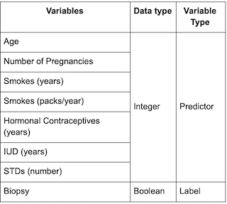

## 2.2 Exploratory Data Analysis (EDA)

### 2.2.1 Initial Data Wrangling and Cleaning

We can perform initial exploratory data analysis to learn more about our dataset.

First, we download the file off the web and read the data into R.

```r
#Load required packages
library(tidyverse)
library(repr)
library(caret)
library(GGally)

#Read file into R. We specify the NA character as "?" for easy removal of NAs later.
cervical_data_raw <- read_csv("https://archive.ics.uci.edu/ml/machine-learning-databases/00383/risk_factors_cervical_cancer.csv", na = "?")

#Preview the dataset
head(cervical_data_raw)
```

A tibble: 6 × 36

| Age <dbl> | Number of sexual partners <dbl> | First sexual intercourse <dbl> | Num of pregnancies <dbl> | Smokes <dbl> | Smokes (years) <dbl> | Smokes (packs/year) <dbl> | Hormonal Contraceptives <dbl> | Hormonal Contraceptives (years) <dbl> | IUD <dbl> | ⋯ | STDs: Time since first diagnosis <dbl> | STDs: Time since last diagnosis <dbl> | Dx:Cancer <dbl> | Dx:CIN <dbl> | Dx:HPV <dbl> | Dx <dbl> | Hinselmann <dbl> | Schiller <dbl> | Citology <dbl> | Biopsy <dbl> |
| --- | --- | --- | --- | --- | --- | --- | --- | --- | --- | --- | --- | --- | --- | --- | --- | --- | --- | --- | --- | --- |
| 18 | 4 | 15 | 1 | 0 | 0 | 0 | 0 | 0 | 0 | ⋯ | NA | NA | 0 | 0 | 0 | 0 | 0 | 0 | 0 | 0 |
| 15 | 1 | 14 | 1 | 0 | 0 | 0 | 0 | 0 | 0 | ⋯ | NA | NA | 0 | 0 | 0 | 0 | 0 | 0 | 0 | 0 |
| 34 | 1 | NA | 1 | 0 | 0 | 0 | 0 | 0 | 0 | ⋯ | NA | NA | 0 | 0 | 0 | 0 | 0 | 0 | 0 | 0 |
| 52 | 5 | 16 | 4 | 1 | 37 | 37 | 1 | 3 | 0 | ⋯ | NA | NA | 1 | 0 | 1 | 0 | 0 | 0 | 0 | 0 |
| 46 | 3 | 21 | 4 | 0 | 0 | 0 | 1 | 15 | 0 | ⋯ | NA | NA | 0 | 0 | 0 | 0 | 0 | 0 | 0 | 0 |
| 42 | 3 | 23 | 2 | 0 | 0 | 0 | 0 | 0 | 0 | ⋯ | NA | NA | 0 | 0 | 0 | 0 | 0 | 0 | 0 | 0 |

To begin wrangling the dataset, we remove the spaces from the column names for easier manipulation.

```r
#convert column names to data-wrangling friendly format
col_names_vector <-make.names(names(cervical_data_raw),unique = TRUE)
colnames(cervical_data_raw) <- c(col_names_vector)
```

The variables we will use for the classifier are then selected and any rows with missing observations are removed.

We also change the Biopsy labels here to more easily interpretable names, with the "0" being changed to "benign" (non-cancerous), and "1" being changed to "malignant" (cancerous). We also convert the target variable into a factor for ease of processing.

```r
#select the variables we chose
cervical_data <- cervical_data_raw %>%
    select(Age, Num.of.pregnancies, Smokes..years., Smokes..packs.year., Hormonal.Contraceptives..years.,
           IUD..years., STDs..number., Biopsy)

#remove any NAs
cervical_data <- na.omit(cervical_data)

#change the Biopsy label 0 to "negative" for ease of reading
cervical_data$Biopsy <- str_replace(cervical_data$Biopsy, "0", "benign")

#change the Biopsy label 1 to "positive" for ease of reading
cervical_data$Biopsy <- str_replace(cervical_data$Biopsy, "1", "malignant")

#convert target variable into a factor
cervical_data$Biopsy <- as.factor(cervical_data$Biopsy)
```

The dataset is then split into a training and test set for proper model building. 75% of the observations are used for the training set to make the model, while the other 25% will be the test set used to test the model’s accuracy. A seed is set because the data partition will be random so the seed will be necessary for the results to be reproducible.

```r
#set seed for reproducability
set.seed(1111)

#partition data into training set
training_rows <- cervical_data%>%
    select(Biopsy)%>%
    unlist()%>%
    createDataPartition(p=0.75, list=FALSE)
training_set <- cervical_data%>% slice(training_rows) %>% data.frame()
```

### 2.2.2 Summary Table of Training Set

The training dataset was used to create a table of exploratory data after our initial cleaning process. This included the number of observations, means of the variables, as well as the number of observations for each label class. First the means of all the variables were gotten. A new dataframe was made containing initial statistics of the dataset. The two dataframes were combined and then made into a table.

```r
#create dataframe of means for the variables
mean_columns <- training_set%>%select(-c(Biopsy))
mean_predictors <- mean_columns%>%
    map_df(mean, na.rm  = T)

#create another summary table of statistics
summary_data <- data.frame("Number_of_Obs" = nrow(training_set),
          "Number_of_Original_Variables" = 36,
          "Number_of_Variables_Used_in_Model" = 7,
           "Rows_with_Missing Data_in_Useful_Variables" = 130,
            "Number_of_Positive_Labels" = sum(training_set$Biopsy == "malignant"),
           "Number_of_Negative_Labels" = sum(training_set$Biopsy == "benign"))

#combine the two tables, rounding the numbers for ease of reading
summary_table <- round((cbind(summary_data, mean_predictors)), 2)

#change column names for ease of interpretation
colnames(summary_table) <- c("Number of Observations (NA removed)",
                             "Number of Original Variables",
                            "Number of Variables Used in Model",
                            "Rows with Missing Data in Useful Variables (Removed)",
                            "Number of Positive Labels (Cancerous)",
                            "Number of Negative Labels (Non-Cancerous)",
                            "Mean Age",
                            "Mean Number of Pregnancies",
                            "Mean Years Smoked",
                            "Mean Cigarette Packs/Year",
                            "Mean Years using Hormonal Contraceptives",
                            "Mean Years with an IUD",
                            "Mean Number of STDs")


summary_table
```

A data.frame: 1 × 13

[output not shown]

An important point to note would be the imbalance in number of observations in each class. This means that upsampling must be done later on when building the model.

### 2.2.3 Visualizing Distributions

We can also visualize the distributions and relationships between variables by using the ggpairs function.

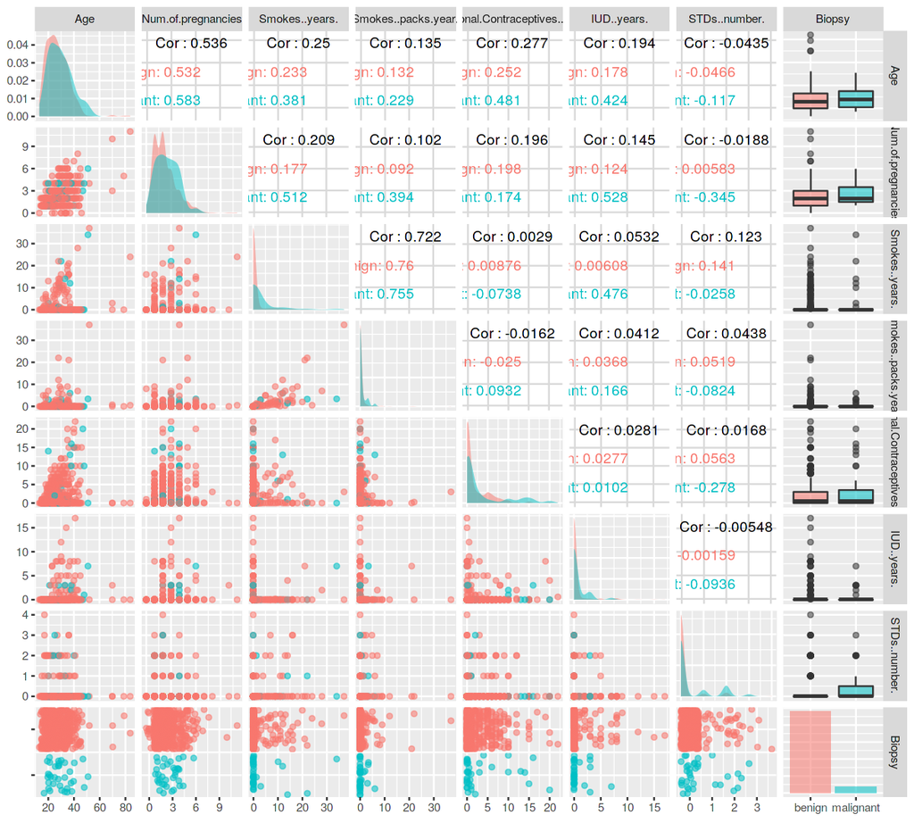

```r
#set plot width and height
options(repr.plot.height=9,repr.plot.width=10)

#create distribution and correlation plots for visualization
eda_plots <-training_set%>%
    ggpairs(mapping = aes(colour=Biopsy, alpha = 0.5),
            lower = list(combo = wrap("dot")),
           diag = list(continuous = wrap("densityDiag", alpha=0.5, color = NA )))

#view plot
eda_plots
```

As we are comparing the predictors to Biopsy, the label, the bottom row and right columns can be used to see the relationship between a positive or negative biopsy result when compared to the predictors. The bottom row of histograms show the results of biopsy at different observations from the predictors. There is a separate plot for the spread for positive results and another plot for negative results.

We can see that there is no variable directly correlated to the Biopsy label (positive or negative). There are more negative labels (red) than positive labels (blue), but the overall distribution of points across labels are not obviously different across all variables. Thus, our model will likely not significantly rely on one variable, but a combination of all these variables.

## 2.3 Building the Classifier

Having done EDA, we can now construct the knn classification model. To begin, we must perform certain data preprocessing steps to ensure our model will be as unbiased and accurate as possible.

Firstly, the previously cleaned and wrangled data set is scaled to ensure proper centering and standardization of all variables, so that certain variables will not have more influence on the distances used for the k-nn classification algorithm.

```r
#scale all the variables except the target label Biopsy
scaled_data <- cervical_data %>%
    select(-c(Biopsy)) %>%
    scale(center = TRUE)

#create a dataframe combining newly scaled data and target label Biopsy
scaled_data <- data.frame(scaled_data, Biopsy = cervical_data$Biopsy)

#preview data
head(scaled_data)
```

A data.frame: 6 × 8

| Age <dbl> | Num.of.pregnancies <dbl> | Smokes..years. <dbl> | Smokes..packs.year. <dbl> | Hormonal.Contraceptives..years. <dbl> | IUD..years. <dbl> | STDs..number. <dbl> | Biopsy <fct> |
| --- | --- | --- | --- | --- | --- | --- | --- |
| -1.0734894 | -0.8978109 | -0.2957363 | -0.198566 | -0.6134426 | -0.261312 | -0.2996217 | benign |
| -1.4192065 | -0.8978109 | -0.2957363 | -0.198566 | -0.6134426 | -0.261312 | -0.2996217 | benign |
| 0.7703351 | -0.8978109 | -0.2957363 | -0.198566 | -0.6134426 | -0.261312 | -0.2996217 | benign |
| 2.8446377 | 1.1453801 | 8.4368482 | 15.758835 | 0.1989074 | -0.261312 | -0.2996217 | benign |
| 2.1532035 | 1.1453801 | -0.2957363 | -0.198566 | 3.4483074 | -0.261312 | -0.2996217 | benign |
| 1.6922474 | -0.2167473 | -0.2957363 | -0.198566 | -0.6134426 | -0.261312 | -0.2996217 | benign |

The full scaled data set is then split into training and test sets again using the same rows generated from the data partition initially.

```r
#create the training and testing data sets from the scaled data
training_set_scaled <- scaled_data %>% slice(training_rows)
testing_set_scaled <- scaled_data %>% slice(-training_rows)
```

Initially, the dataset has far fewer observations in the positive class. Therefore, upsampling is required to balance the number of observations in each class label.

```r
#Balance the training data with upSample()
training_upsample <- upSample( x = select(training_set_scaled, -c(Biopsy)),
                                    y = select(training_set_scaled, Biopsy) %>% unlist())

#change column name back to "Biopsy"
colnames(training_upsample)[8] <- "Biopsy"
```

```r
#show table of frequencies of each label after upsampling
training_upsample_rows <- training_upsample %>%
    group_by(Biopsy) %>%
    summarize(n = n())

#show table of frequences for each biopsy label in the training set
no_upsample <- training_set_scaled%>%
    group_by(Biopsy)%>%
    summarize(n=n())

#add comment for clarity
comment(no_upsample) <- "Before upSample"
comment(no_upsample)
no_upsample

comment(training_upsample_rows) <- "After upSample"
comment(training_upsample_rows)
training_upsample_rows
```

'Before upSample'

A tibble: 2 × 2

| Biopsy <fct> | n <int> |
| --- | --- |
| benign | 480 |
| malignant | 35 |

'After upSample'

A tibble: 2 × 2

| Biopsy <fct> | n <int> |
| --- | --- |
| benign | 480 |
| malignant | 480 |

Here we can see the effects of upsampling; it changes the number of observations in the malignant class from 35 to 480, the same as benign observations. This essentially gives a single malignant observation more voting influence so that benign cases do not completely influence the classification.

This training set can then made into arguments to be used for the model.

```r
#split data into the x_train and y_train arguments for model building
x_train_upsample <- training_upsample %>%
    select(-Biopsy) %>%
    data.frame()
y_train_upsample <- training_upsample %>%
    select(Biopsy) %>%
    unlist()
```

A dataframe of k-values is made and used in the train_control function for cross-validation purposes. Only odd numbers were used to avoid any ties in the voting function of the knn algorithm. We then train our model with 10-fold cross validation to determine optimal values of k.

```r
#create sequence of k values to use for testing
ks <- data.frame(k = seq(from = 1, to = 50, by = 2))

#set cross validation parameters for 10-fold cross validation
train_control <- trainControl(method = "cv", number = 10)

#set seed for reproducability
set.seed(4444)

#train model with 10-fold cross validation
knn_test_upsample <- train(x = x_train_upsample, y = y_train_upsample, method = "knn", tuneGrid = ks, trControl = train_control)
knn_test_upsample
```

```
k-Nearest Neighbors

960 samples
  7 predictor
  2 classes: 'benign', 'malignant'

No pre-processing
Resampling: Cross-Validated (10 fold)
Summary of sample sizes: 864, 864, 864, 864, 864, 864, ...
Resampling results across tuning parameters:

  k   Accuracy   Kappa
   1  0.9500000  0.9000000
   3  0.8937500  0.7875000
   5  0.8479167  0.6958333
```

[output cut: 25 more lines]

We can plot these values to visually assess accuracy of k across values:

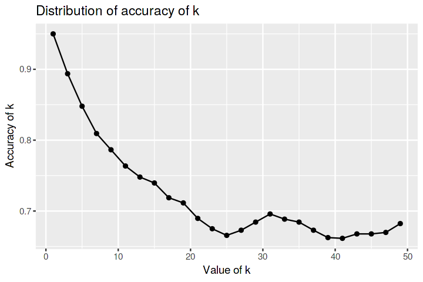

```r
#select appropriate columns for plotting
ks_accuracies_upsample <- knn_test_upsample$results %>%
                    select(k, Accuracy)

#create plot
ks_plot_upsample <- ks_accuracies_upsample %>%
    ggplot(aes(x = k, y = Accuracy)) +
    geom_point() +
    labs(x = "Value of k", y = "Accuracy of k") +
    geom_line() +
    ggtitle("Distribution of accuracy of k")

#set plot width and height
options(repr.plot.width = 6, repr.plot.height = 4)

#view plot
ks_plot_upsample
```

A training set with scaled but not upsampled observations was used to see what proportions of predictions were being made for k = 1, 3, 5, 7, 9 (the best candidates for optimal k-values).

```r
#create training sets
x_train_scaled <- training_set_scaled %>% select(-Biopsy) %>% data.frame()
y_train_scaled <- training_set_scaled %>% select(Biopsy) %>% unlist()
```

```r
#-----------------------------
#K = 1
#-----------------------------

#create k=1 dataframe
k1 <- data.frame(k = 1)

#train model with k=1
model_k1 <- train(x = x_train_upsample, y = y_train_upsample, method = 'knn', tuneGrid = k1)

#assess prediction accuracy on training set
prediction_k1 <- predict(object = model_k1, x_train_scaled)

#visualize prediction results
pred_results_k1 <- confusionMatrix(prediction_k1, y_train_scaled)
pred_results_k1

#create summary table for results
accuracy_summary_k1 <- as.data.frame(as.table(pred_results_k1))
accuracy_summary_k1 <- accuracy_summary_k1 %>% mutate(Proportion = Freq/sum(Freq))

#-----------------------------
#K = 3
#-----------------------------

#create k=3 dataframe
k3 <- data.frame(k = 3)

#train model with k=3
model_k3 <- train(x = x_train_upsample, y = y_train_upsample, method = 'knn', tuneGrid = k3)

#assess prediction accuracy on training set
prediction_k3 <- predict(object = model_k3, x_train_scaled)

#visualize prediction results
pred_results_k3 <- confusionMatrix(prediction_k3, y_train_scaled)
pred_results_k3

#create summary table for results
accuracy_summary_k3 <- as.data.frame(as.table(pred_results_k3))
accuracy_summary_k3 <- accuracy_summary_k3 %>% mutate(Proportion = Freq/sum(Freq))

#-----------------------------
#K = 5
#-----------------------------

#create k=5 dataframe
k5 <- data.frame(k = 5)

#train model with k=5
model_k5 <- train(x = x_train_upsample, y = y_train_upsample, method = 'knn', tuneGrid = k5)

#assess prediction accuracy on training set
prediction_k5 <- predict(object = model_k5, x_train_scaled)

#visualize prediction results
pred_results_k5 <- confusionMatrix(prediction_k5, y_train_scaled)
pred_results_k5

#create summary table for results
accuracy_summary_k5 <- as.data.frame(as.table(pred_results_k5))
accuracy_summary_k5 <- accuracy_summary_k5 %>% mutate(Proportion = Freq/sum(Freq))

#-----------------------------
#K = 7
#-----------------------------

#create k=7 dataframe
k7 <- data.frame(k = 7)

#train model with k=7
model_k7 <- train(x = x_train_upsample, y = y_train_upsample, method = 'knn', tuneGrid = k7)

#assess prediction accuracy on training set
prediction_k7 <- predict(object = model_k7, x_train_scaled)

#visualize prediction results
pred_results_k7 <- confusionMatrix(prediction_k7, y_train_scaled)
pred_results_k7

#create summary table for results
accuracy_summary_k7 <- as.data.frame(as.table(pred_results_k7))
accuracy_summary_k7 <- accuracy_summary_k7 %>% mutate(Proportion = Freq/sum(Freq))

#-----------------------------
#K = 9
#-----------------------------

#create k=9 dataframe
k9 <- data.frame(k = 9)

#train model with k=9
model_k9 <- train(x = x_train_upsample, y = y_train_upsample, method = 'knn', tuneGrid = k9)

#assess prediction accuracy on training set
prediction_k9 <- predict(object = model_k9, x_train_scaled)

#visualize prediction results
pred_results_k9 <- confusionMatrix(prediction_k9, y_train_scaled)
pred_results_k9

#create summary table for results
accuracy_summary_k9 <- as.data.frame(as.table(pred_results_k9))
accuracy_summary_k9 <- accuracy_summary_k9 %>% mutate(Proportion = Freq/sum(Freq))
```

```
Confusion Matrix and Statistics

           Reference
Prediction  benign malignant
  benign       467         0
  malignant     13        35

               Accuracy : 0.9748
                 95% CI : (0.9572, 0.9865)
    No Information Rate : 0.932
    P-Value [Acc > NIR] : 1.12e-05

                  Kappa : 0.83

 Mcnemar's Test P-Value : 0.0008741

            Sensitivity : 0.9729
            Specificity : 1.0000
         Pos Pred Value : 1.0000
         Neg Pred Value : 0.7292
             Prevalence : 0.9320
         Detection Rate : 0.9068
   Detection Prevalence : 0.9068
      Balanced Accuracy : 0.9865

       'Positive' Class : benign
```

```
Confusion Matrix and Statistics

           Reference
Prediction  benign malignant
  benign       411         0
  malignant     69        35

               Accuracy : 0.866
                 95% CI : (0.8335, 0.8942)
    No Information Rate : 0.932
    P-Value [Acc > NIR] : 1

                  Kappa : 0.4474

 Mcnemar's Test P-Value : 2.695e-16

            Sensitivity : 0.8562
            Specificity : 1.0000
         Pos Pred Value : 1.0000
         Neg Pred Value : 0.3365
             Prevalence : 0.9320
         Detection Rate : 0.7981
   Detection Prevalence : 0.7981
      Balanced Accuracy : 0.9281

       'Positive' Class : benign
```

```
Confusion Matrix and Statistics

           Reference
Prediction  benign malignant
  benign       368         0
  malignant    112        35

               Accuracy : 0.7825
                 95% CI : (0.7444, 0.8174)
    No Information Rate : 0.932
    P-Value [Acc > NIR] : 1

                  Kappa : 0.3087

 Mcnemar's Test P-Value : <2e-16

            Sensitivity : 0.7667
            Specificity : 1.0000
         Pos Pred Value : 1.0000
         Neg Pred Value : 0.2381
             Prevalence : 0.9320
         Detection Rate : 0.7146
   Detection Prevalence : 0.7146
      Balanced Accuracy : 0.8833

       'Positive' Class : benign
```

```
Confusion Matrix and Statistics

           Reference
Prediction  benign malignant
  benign       326         0
  malignant    154        35

               Accuracy : 0.701
                 95% CI : (0.6594, 0.7402)
    No Information Rate : 0.932
    P-Value [Acc > NIR] : 1

                  Kappa : 0.2234

 Mcnemar's Test P-Value : <2e-16

            Sensitivity : 0.6792
            Specificity : 1.0000
         Pos Pred Value : 1.0000
         Neg Pred Value : 0.1852
             Prevalence : 0.9320
         Detection Rate : 0.6330
   Detection Prevalence : 0.6330
      Balanced Accuracy : 0.8396

       'Positive' Class : benign
```

```
Confusion Matrix and Statistics

           Reference
Prediction  benign malignant
  benign       297         0
  malignant    183        35

               Accuracy : 0.6447
                 95% CI : (0.6016, 0.686)
    No Information Rate : 0.932
    P-Value [Acc > NIR] : 1

                  Kappa : 0.1807

 Mcnemar's Test P-Value : <2e-16

            Sensitivity : 0.6188
            Specificity : 1.0000
         Pos Pred Value : 1.0000
         Neg Pred Value : 0.1606
             Prevalence : 0.9320
         Detection Rate : 0.5767
   Detection Prevalence : 0.5767
      Balanced Accuracy : 0.8094

       'Positive' Class : benign
```

```r
#ADD COMMENTS FOR CLARITY

comment(accuracy_summary_k1) <- "K = 1"
comment(accuracy_summary_k1)
accuracy_summary_k1

comment(accuracy_summary_k3) <- "K = 3"
comment(accuracy_summary_k3)
accuracy_summary_k3

comment(accuracy_summary_k5) <- "K = 5"
comment(accuracy_summary_k5)
accuracy_summary_k5

comment(accuracy_summary_k7) <- "K = 7"
comment(accuracy_summary_k7)
accuracy_summary_k7

comment(accuracy_summary_k9) <- "K = 9"
comment(accuracy_summary_k9)
accuracy_summary_k9
```

'K = 1'

A data.frame: 4 × 4

| Prediction <fct> | Reference <fct> | Freq <int> | Proportion <dbl> |
| --- | --- | --- | --- |
| benign | benign | 467 | 0.90679612 |
| malignant | benign | 13 | 0.02524272 |
| benign | malignant | 0 | 0.00000000 |
| malignant | malignant | 35 | 0.06796117 |

'K = 3'

A data.frame: 4 × 4

| Prediction <fct> | Reference <fct> | Freq <int> | Proportion <dbl> |
| --- | --- | --- | --- |
| benign | benign | 411 | 0.79805825 |
| malignant | benign | 69 | 0.13398058 |
| benign | malignant | 0 | 0.00000000 |
| malignant | malignant | 35 | 0.06796117 |

'K = 5'

A data.frame: 4 × 4

| Prediction <fct> | Reference <fct> | Freq <int> | Proportion <dbl> |
| --- | --- | --- | --- |
| benign | benign | 368 | 0.71456311 |
| malignant | benign | 112 | 0.21747573 |
| benign | malignant | 0 | 0.00000000 |
| malignant | malignant | 35 | 0.06796117 |

'K = 7'

A data.frame: 4 × 4

| Prediction <fct> | Reference <fct> | Freq <int> | Proportion <dbl> |
| --- | --- | --- | --- |
| benign | benign | 326 | 0.63300971 |
| malignant | benign | 154 | 0.29902913 |
| benign | malignant | 0 | 0.00000000 |
| malignant | malignant | 35 | 0.06796117 |

'K = 9'

A data.frame: 4 × 4

| Prediction <fct> | Reference <fct> | Freq <int> | Proportion <dbl> |
| --- | --- | --- | --- |
| benign | benign | 297 | 0.57669903 |
| malignant | benign | 183 | 0.35533981 |
| benign | malignant | 0 | 0.00000000 |
| malignant | malignant | 35 | 0.06796117 |

## 2.4.0 Evaluating Classifier on Test Set

The final model with the chosen k-value can be made. The test set, after splitting the labels from the observations, can then be used with the model to evaluate its accuracy by having the model predict the labels when given the test observations. These are then compared to the actual labels to get the accuracy of the model.

```r
#The testing sets are made with just the scaled data.

x_test_scaled <- testing_set_scaled%>%
    select(-(Biopsy))%>%
    data.frame()

y_test_scaled <- testing_set_scaled%>%
    select(Biopsy)%>%
    unlist()
```

Here we use our test set that has been scaled to see the test accuracy of our model with the chosen variables and k=3.

```r
#create test set predictions
test_prediction<- predict(object = model_k3, x_test_scaled)

#use confusion matrix to assess prediction accuracy
pred_results_test <- confusionMatrix(test_prediction, y_test_scaled)

#view results
pred_results_test
```

```
Confusion Matrix and Statistics

           Reference
Prediction  benign malignant
  benign       126         8
  malignant     33         3

               Accuracy : 0.7588
                 95% CI : (0.6874, 0.821)
    No Information Rate : 0.9353
    P-Value [Acc > NIR] : 1.0000000

                  Kappa : 0.0317

 Mcnemar's Test P-Value : 0.0001781

            Sensitivity : 0.79245
            Specificity : 0.27273
         Pos Pred Value : 0.94030
         Neg Pred Value : 0.08333
             Prevalence : 0.93529
         Detection Rate : 0.74118
   Detection Prevalence : 0.78824
      Balanced Accuracy : 0.53259

       'Positive' Class : benign
```

## 2.5.0 Visualizing Classifier Results

We can use the pairs() function to visualize our classification results more clearly across the two labels:

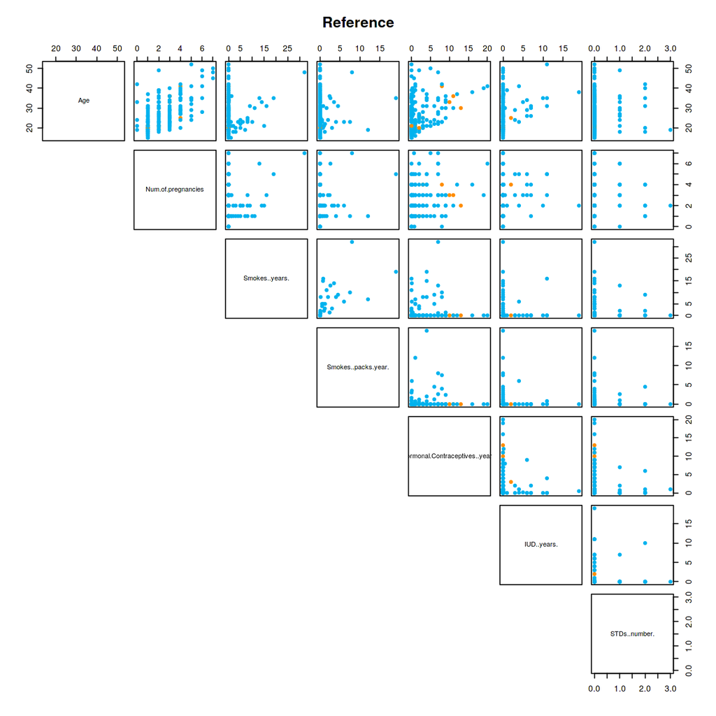

```r
#call the testing set that is not scaled for ease of interpretation
testing_set <-cervical_data%>%slice(-training_rows)

#set preferred colours
my_cols <-c('deepskyblue2','dark orange')

#set plot width and height
options(repr.plot.height=10, repr.plot.width=10)

#make plot
pairs(testing_set[,1:7],pch=20,col=my_cols[cervical_data$Biopsy], lower.panel = NULL, main = "Reference")
```

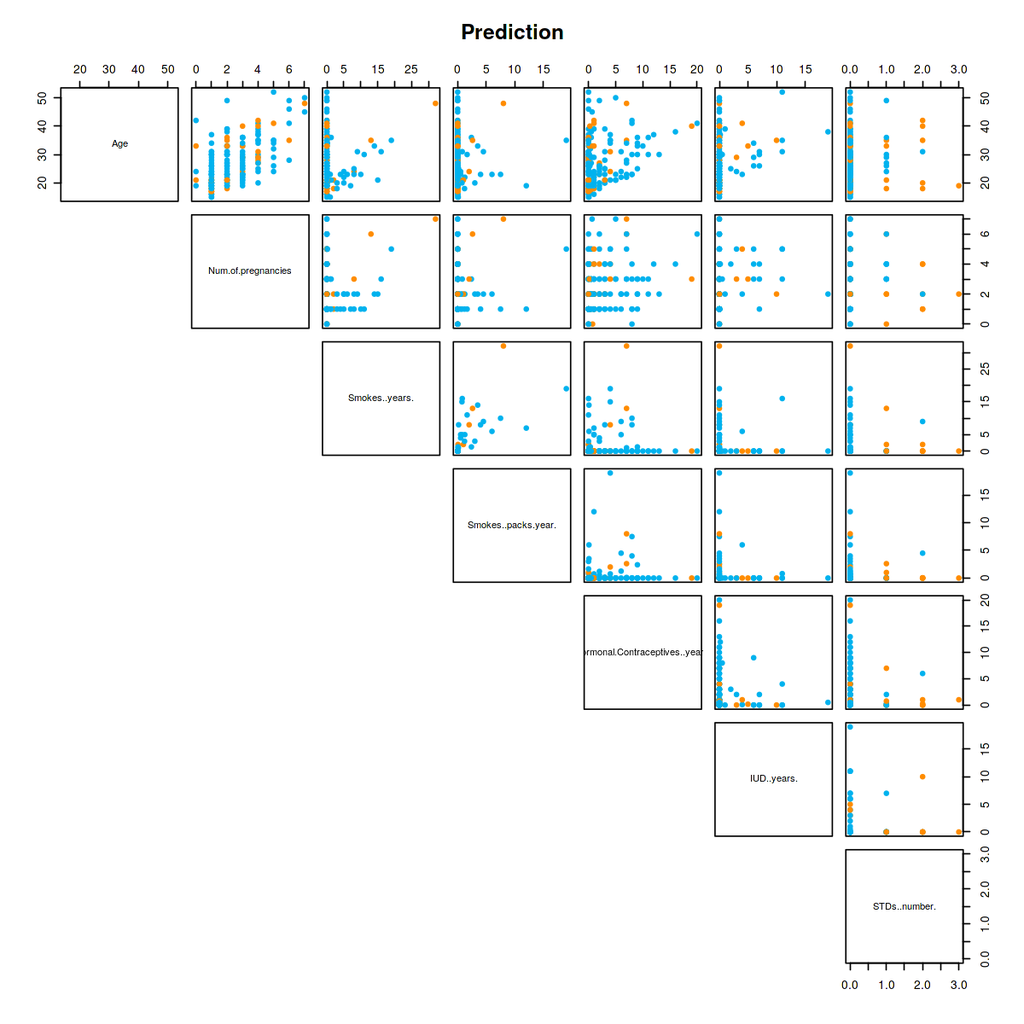

```r
#call the testing set that is not scaled for ease of interpretation
testing_set <-cervical_data%>%slice(-training_rows)

#create dataframe for visualization
test_prediction_for_viz <- data.frame(testing_set, test_prediction)

#set preferred colours
my_cols <-c('deepskyblue2','dark orange')

#plot results
pairs(test_prediction_for_viz[,1:7],pch=20,col=my_cols[test_prediction_for_viz$test_prediction], lower.panel = NULL, main = "Prediction")
```

The testing set was made into an array of plots that show the variables in relationship to each other with the actual labels shown by colour. An additional plot of the predicted labels was shown underneath. These visualizations demonstrate the higher tendency for the model to predict malignant as the class (more orange=more malignant labels). It also shows that there is no obvious grouping that correlates to higher chances of predicted malignant cases meaning that single points are not influencing entire regions to be malignant.

# 3.0.0 Discussion:

The goal of our project was to identify risk factors predictive of cancer and to see if we could use these factors to build a model capable of classifying patients as likely having cancer (malignant) or not (benign).

```r
#visualize summary table of model accuracy by class
t(pred_results_test$byClass)

#NOTE THAT POSITIVE VALUE IN THE TABLE ARE BENIGN CASES

#visualize summary table of overall model accuracy
t(pred_results_test$overall)

#visualize predicted table of results
pred_results_test$table
```

A matrix: 1 × 11 of type dbl

| Sensitivity | Specificity | Pos Pred Value | Neg Pred Value | Precision | Recall | F1 | Prevalence | Detection Rate | Detection Prevalence | Balanced Accuracy |
| --- | --- | --- | --- | --- | --- | --- | --- | --- | --- | --- |
| 0.7924528 | 0.2727273 | 0.9402985 | 0.08333333 | 0.9402985 | 0.7924528 | 0.8600683 | 0.9352941 | 0.7411765 | 0.7882353 | 0.5325901 |

A matrix: 1 × 7 of type dbl

| Accuracy | Kappa | AccuracyLower | AccuracyUpper | AccuracyNull | AccuracyPValue | McnemarPValue |
| --- | --- | --- | --- | --- | --- | --- |
| 0.7588235 | 0.03167547 | 0.6873654 | 0.821029 | 0.9352941 | 1 | 0.0001781293 |

```
           Reference
Prediction  benign malignant
  benign       126         8
  malignant     33         3
```

Potentially, this model could be used to screen out patient subgroup populations who are not high-risk, and do not need close medical attention/follow up, which could potentially be used to cut down on medical costs and free up valuable time of health professionals.

Further work could potentially be based on identifying irrelevant variables to filter out using more statistically rigorous methods. For example, future research could perhaps employ advanced dimensionality reduction methods to further improve model accuracy, such as in principle component analysis.

# References

1. Cervical Cancer - Statistics. (2019, June 10). Retrieved from https://www.cancer.net/cancer-types/cervical-cancer/statistics.
2. Cervical cancer. (2019, July 31). Retrieved from https://www.mayoclinic.org/diseases-conditions/cervical-cancer/diagnosis-treatment/drc-20352506.4